# Cerebral Stroke Diagnosis based on physiological Factors

```r
  theme_classic()
```

[output not shown]

[output cut: 356 more lines]

[output not shown]

So, based on above analysis, smoking status might be related to work type and we might be able to fill few values using this plot

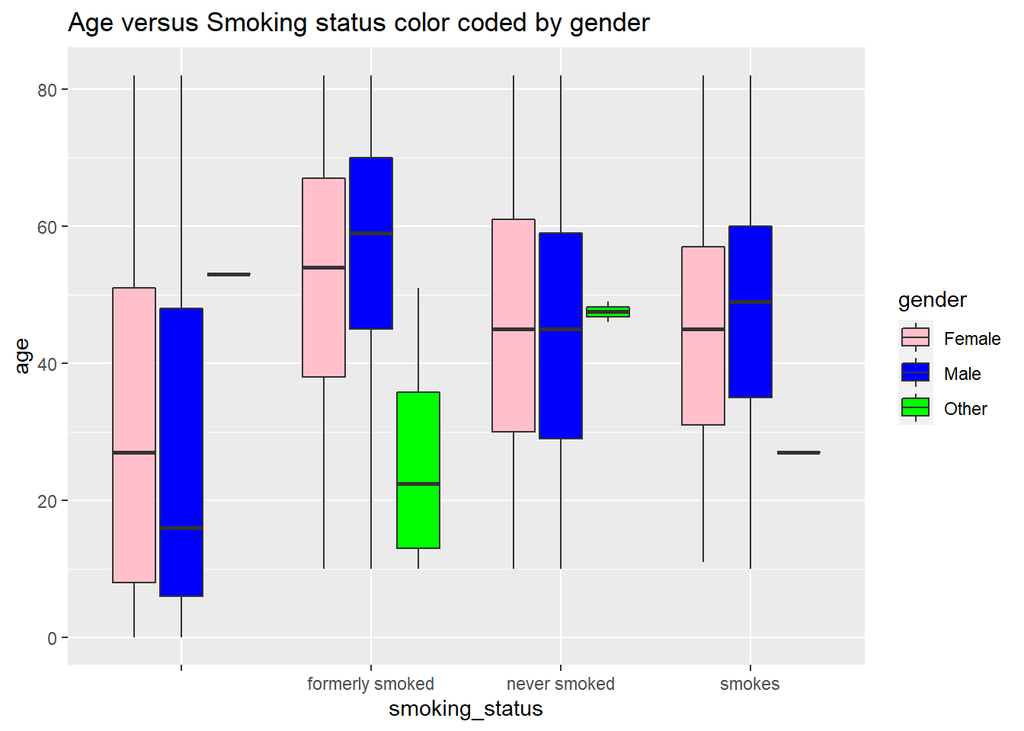

```r
ggplot(brainData, aes(x = smoking_status, y = age, fill = gender)) +
  geom_boxplot() +
  scale_fill_manual(values = c("pink", "blue", "green")) +
  labs(title = "Age versus Smoking status color coded by gender")
```

```r
  theme_classic()
```

[output not shown]

[output cut: 356 more lines]

[output not shown]

The plot of gender for male and female is almost similar for all three category.  
There are only few entries for others, so it’s not providing important relations

Hence, from the above plot gender is not affecting smoking status and we cannot fill our missing values using that.

*Hypothesis Testing for finding Correlation*

```r
aov1 = aov(age~smoking_status , cleanData)
summary(aov1)
```

```
##                   Df   Sum Sq Mean Sq F value Pr(>F)
## smoking_status     2   467985  233993     647 <2e-16 ***
## Residuals      36981 13374147     362
## ---
## Signif. codes:  0 '***' 0.001 '**' 0.01 '*' 0.05 '.' 0.1 ' ' 1
```

With the p-value <2e-16, we can see that smoking_status and age are related

Hence, the only variable slightly related to fill out the missing values is age. But due to Class Imbalance data and out of 13292 Missing values 5250 being children, we will directly drop the unknown values rows.